# Integration of GWAS, Gene Expression, ncRNA, ChIP-seq & QTL Concepts

Genomics End Semester Project

2026-08-31

# 1 Introduction

This document integrates results from all previous tasks of the Genomics End Semester Project to identify **candidate genes** potentially involved in the studied disease condition. We bring together four independent lines of genomic evidence:

| Task | Data Type | File Used |
| --- | --- | --- |
| DEG Analysis | Differential Gene Expression (RNA-seq) | `DEG_results_significant.csv` |
| ncRNA Analysis | ncRNA / miRNA Regulatory Interactions | `task4_interactions_complete.xlsx` |
| ChIP-seq Analysis | CTCF ChIP-seq Annotated Peaks | `CTCF_annotated_peaks.csv` |
| GWAS Analysis | GWAS Significant SNPs | `GWAS_GW_significant_SNPs.csv` |

Genes supported by **multiple evidence layers** are the strongest candidate genes for the disease under study.

# 2 Step 1: Load Libraries

```r
# Install packages only once - uncomment and run if not already installed
# install.packages(c("dplyr", "ggplot2", "ggvenn", "readxl",
#                    "writexl", "RColorBrewer", "ggrepel", "tidyr", "knitr"))

library(dplyr)        # Data manipulation: filter, merge, select, mutate
library(ggplot2)      # High-quality data visualizations
library(ggvenn)       # Venn diagrams for overlapping gene sets
library(readxl)       # Read Excel (.xlsx) files
library(writexl)      # Write output to Excel
library(RColorBrewer) # Color palettes for plots
library(ggrepel)      # Non-overlapping text labels on plots
library(tidyr)        # Data reshaping (pivot_longer)
library(knitr)        # Nicely formatted tables in the HTML output
```

# 3 Step 2: Load All Input Files

```r
# ── Significant DEGs ─────────────────────────────────────────────────
# Filtered DEGs from DESeq2 analysis (padj < 0.01)
# Gene IDs are in Ensembl format (e.g. ENSG00000118113)
deg <- read.csv("DEG_results_significant.csv", stringsAsFactors = FALSE)
cat("DEGs loaded:", nrow(deg), "significant genes\n")
```

```
## DEGs loaded: 1459 significant genes
```

```r
# ── ncRNA Interactions ───────────────────────────────────────────────
# miRNA-target gene interactions predicted from miRDB
# Target genes are in gene symbol format (e.g. MMP8, CD209)
ncrna <- read_excel("task4_interactions_complete.xlsx",
                    sheet = "ncRNA Interactions")
ncrna <- as.data.frame(ncrna)
cat("ncRNA interactions loaded:", nrow(ncrna), "rows\n")
```

```
## ncRNA interactions loaded: 130 rows
```

```r
# ── CTCF ChIP-seq Annotated Peaks ───────────────────────────────────
# ChIP-seq peaks annotated to nearby genes using ChIPseeker
# Contains both ENSEMBL IDs and SYMBOL columns — used as our reference map
chipseq <- read.csv("CTCF_annotated_peaks.csv", stringsAsFactors = FALSE)
cat("ChIP-seq peaks loaded:", nrow(chipseq), "annotated peaks\n")
```

```
## ChIP-seq peaks loaded: 42243 annotated peaks
```

```r
# ── GWAS Significant SNPs ────────────────────────────────────────────
# Genome-wide significant SNPs (p < 5×10⁻⁸) with chromosome and position
gwas <- read.csv("GWAS_GW_significant_SNPs.csv", stringsAsFactors = FALSE)
cat("GWAS SNPs loaded:", nrow(gwas), "significant SNPs\n")
```

```
## GWAS SNPs loaded: 28 significant SNPs
```

# 4 Step 3: Prepare Gene Lists from Each Data Source

The main challenge here is that each task uses a **different gene identifier format**. We standardize everything to Ensembl IDs for comparison.

```r
# ── 3A: DEG gene list ────────────────────────────────────────────────────────
# DEGs already use Ensembl IDs — just extract the unique set
deg_ensembl <- unique(deg$gene)
cat("Unique DEG Ensembl IDs:", length(deg_ensembl), "\n")
```

```
## Unique DEG Ensembl IDs: 1459
```

```r
# ── 3B: ChIP-seq gene list ───────────────────────────────────────────────────
# Remove peaks not annotated to any gene (NA in ENSEMBL or SYMBOL columns)
# These unannotated peaks are in intergenic regions and cannot be linked to genes
chipseq_clean <- chipseq %>%
  filter(!is.na(ENSEMBL) & ENSEMBL != "" & !is.na(SYMBOL)) %>%
  select(ENSEMBL, SYMBOL) %>%
  distinct()

chipseq_ensembl <- unique(chipseq_clean$ENSEMBL)
chipseq_symbols  <- unique(chipseq_clean$SYMBOL)
cat("Unique CTCF target genes (Ensembl):", length(chipseq_ensembl), "\n")
```

```
## Unique CTCF target genes (Ensembl): 14681
```

```r
# ── 3C: ncRNA target gene list ───────────────────────────────────────────────
# Filter out rows where no miRNA was found (marked as "N/A")
ncrna_clean <- ncrna %>%
  filter(miRNA != "N/A" & `Target Gene` != "N/A")

ncrna_targets_symbols <- unique(ncrna_clean$`Target Gene`)
cat("Unique ncRNA target gene symbols:", length(ncrna_targets_symbols), "\n")
```

```
## Unique ncRNA target gene symbols: 7
```

```r
cat("Target genes:", paste(ncrna_targets_symbols, collapse = ", "), "\n")
```

```
## Target genes: IFI27, MMP8, IFIT3, ISG20, CD209, KLRK1, IL23R
```

```r
# Convert ncRNA symbols → Ensembl IDs using ChIP-seq as our reference mapping table
# ChIP-seq data has the most complete SYMBOL↔ENSEMBL mapping
symbol_to_ensembl <- chipseq_clean %>%
  filter(SYMBOL %in% ncrna_targets_symbols) %>%
  select(SYMBOL, ENSEMBL) %>%
  distinct()

ncrna_targets_ensembl <- unique(symbol_to_ensembl$ENSEMBL)
cat("ncRNA targets successfully mapped to Ensembl:",
    length(ncrna_targets_ensembl), "out of", length(ncrna_targets_symbols), "\n")
```

```
## ncRNA targets successfully mapped to Ensembl: 4 out of 7
```

```r
# ── 3D: GWAS locus genes ─────────────────────────────────────────────────────
# GWAS SNPs have positions but no gene IDs. We find genes within ±500kb of each
# SNP using the ChIP-seq annotated peak file as our gene coordinate reference.
# This ±500kb window captures likely regulatory target genes of the SNP.
gwas_locus_genes <- data.frame()

for (i in 1:nrow(gwas)) {
  chr_query <- paste0("chr", gwas$CHR[i])
  bp        <- gwas$BP[i]
  window    <- 500000  # ±500 kilobase window around each SNP

  nearby <- chipseq %>%
    filter(seqnames == chr_query,
           start    >= (bp - window),
           end      <= (bp + window),
           !is.na(ENSEMBL), !is.na(SYMBOL)) %>%
    select(ENSEMBL, SYMBOL) %>%
    distinct() %>%
    mutate(SNP   = gwas$SNP[i],
           SNP_P = gwas$P[i],
           CHR   = gwas$CHR[i],
           BP    = bp)

  gwas_locus_genes <- bind_rows(gwas_locus_genes, nearby)
}

gwas_locus_genes <- gwas_locus_genes %>%
  distinct(ENSEMBL, SYMBOL, .keep_all = TRUE)

gwas_ensembl <- unique(gwas_locus_genes$ENSEMBL)
cat("GWAS locus genes (within ±500kb of SNPs):", length(gwas_ensembl), "\n")
```

```
## GWAS locus genes (within ±500kb of SNPs): 25
```

# 5 Step 4: Find Overlaps Between All Gene Lists

Genes appearing in **multiple evidence layers** are the strongest candidates for disease involvement.

```r
# ── Pairwise overlaps ────────────────────────────────────────────────────────
deg_chipseq_overlap   <- intersect(deg_ensembl, chipseq_ensembl)
deg_ncrna_overlap     <- intersect(deg_ensembl, ncrna_targets_ensembl)
deg_gwas_overlap      <- intersect(deg_ensembl, gwas_ensembl)
chipseq_ncrna_overlap <- intersect(chipseq_ensembl, ncrna_targets_ensembl)
chipseq_gwas_overlap  <- intersect(chipseq_ensembl, gwas_ensembl)
ncrna_gwas_overlap    <- intersect(ncrna_targets_ensembl, gwas_ensembl)

# ── Triple overlap: strongest candidates ─────────────────────────────────────
# Genes that are DEGs AND CTCF targets AND ncRNA-regulated
triple_overlap <- intersect(deg_chipseq_overlap, ncrna_targets_ensembl)

# ── Quadruple overlap ────────────────────────────────────────────────────────
quad_overlap <- intersect(triple_overlap, gwas_ensembl)

# ── Summary table ────────────────────────────────────────────────────────────
overlap_summary <- data.frame(
  Comparison                    = c("DEG ∩ ChIP-seq (CTCF)",
                                    "DEG ∩ ncRNA Targets",
                                    "DEG ∩ GWAS Loci",
                                    "ChIP-seq ∩ ncRNA Targets",
                                    "ChIP-seq ∩ GWAS Loci",
                                    "ncRNA ∩ GWAS Loci",
                                    "Triple (DEG + ChIP + ncRNA)",
                                    "Quadruple (all four)"),
  Number_of_Genes               = c(length(deg_chipseq_overlap),
                                    length(deg_ncrna_overlap),
                                    length(deg_gwas_overlap),
                                    length(chipseq_ncrna_overlap),
                                    length(chipseq_gwas_overlap),
                                    length(ncrna_gwas_overlap),
                                    length(triple_overlap),
                                    length(quad_overlap))
)

kable(overlap_summary,
      caption = "Table 1: Pairwise and Multi-way Gene Set Overlaps",
      align   = c("l", "c"))
```

Table 1: Pairwise and Multi-way Gene Set Overlaps

| Comparison | Number_of_Genes |
| --- | --- |
| DEG ∩ ChIP-seq (CTCF) | 787 |
| DEG ∩ ncRNA Targets | 3 |
| DEG ∩ GWAS Loci | 2 |
| ChIP-seq ∩ ncRNA Targets | 4 |
| ChIP-seq ∩ GWAS Loci | 25 |
| ncRNA ∩ GWAS Loci | 0 |
| Triple (DEG + ChIP + ncRNA) | 3 |
| Quadruple (all four) | 0 |

# 6 Step 5: Build the Integrated Evidence Table

This table is the core deliverable of this Task. Each row is a gene; each column shows whether that gene is supported by a particular evidence layer.

```r
# Pool all genes that appear in at least one evidence layer
all_candidate_ensembl <- unique(c(deg_ensembl, chipseq_ensembl,
                                   ncrna_targets_ensembl, gwas_ensembl))

# Build symbol mapping from ChIP-seq reference
all_symbols_map <- chipseq_clean %>%
  bind_rows(
    data.frame(
      ENSEMBL = ncrna_targets_ensembl,
      SYMBOL  = symbol_to_ensembl$SYMBOL[match(ncrna_targets_ensembl,
                                                symbol_to_ensembl$ENSEMBL)]
    )
  ) %>%
  distinct(ENSEMBL, .keep_all = TRUE)

# Construct the full evidence table
evidence_table <- data.frame(ENSEMBL = all_candidate_ensembl) %>%
  left_join(all_symbols_map, by = "ENSEMBL") %>%
  left_join(deg %>% select(gene, log2FoldChange, padj) %>%
              rename(ENSEMBL = gene),
            by = "ENSEMBL") %>%
  mutate(
    Is_DEG          = ENSEMBL %in% deg_ensembl,
    Is_ChIPseq      = ENSEMBL %in% chipseq_ensembl,
    Is_ncRNA_target = ENSEMBL %in% ncrna_targets_ensembl,
    Is_GWAS_gene    = ENSEMBL %in% gwas_ensembl,
    Evidence_Count  = Is_DEG + Is_ChIPseq + Is_ncRNA_target + Is_GWAS_gene,
    Direction       = case_when(
      Is_DEG & log2FoldChange > 0 ~ "Upregulated",
      Is_DEG & log2FoldChange < 0 ~ "Downregulated",
      TRUE                        ~ "Not a DEG"
    )
  ) %>%
  filter(Evidence_Count >= 2) %>%
  arrange(desc(Evidence_Count), desc(abs(log2FoldChange)))

cat("Genes with ≥2 evidence layers:", nrow(evidence_table), "\n")
```

```
## Genes with ≥2 evidence layers: 811
```

```r
# ── Final candidate gene list ────────────────────────────────────────────────
candidate_genes <- evidence_table %>%
  filter(!is.na(SYMBOL)) %>%
  select(ENSEMBL, SYMBOL, log2FoldChange, padj, Direction,
         Is_DEG, Is_ChIPseq, Is_ncRNA_target, Is_GWAS_gene, Evidence_Count)

# Save to CSV
write.csv(candidate_genes,  "Candidate_Genes.csv",         row.names = FALSE)
write.csv(evidence_table,   "Integrated_Evidence_Table.csv", row.names = FALSE)
write.csv(gwas_locus_genes, "GWAS_Locus_Genes.csv",        row.names = FALSE)

# Show top candidates in the document
kable(candidate_genes %>% filter(Evidence_Count >= 3),
      caption = "Table 2: Top Candidate Genes — Supported by 3 Evidence Layers",
      digits  = 4)
```

Table 2: Top Candidate Genes — Supported by 3 Evidence Layers

| ENSEMBL | SYMBOL | log2FoldChange | padj | Direction | Is_DEG | Is_ChIPseq | Is_ncRNA_target | Is_GWAS_gene | Evidence_Count |
| --- | --- | --- | --- | --- | --- | --- | --- | --- | --- |
| ENSG00000118113 | MMP8 | 4.5458 | 0.0079 | Upregulated | TRUE | TRUE | TRUE | FALSE | 3 |
| ENSG00000162594 | IL23R | -2.3307 | 0.0003 | Downregulated | TRUE | TRUE | TRUE | FALSE | 3 |
| ENSG00000090659 | CD209 | -2.2413 | 0.0015 | Downregulated | TRUE | TRUE | TRUE | FALSE | 3 |
| ENSG00000148296 | SURF6 | -0.6655 | 0.0023 | Downregulated | TRUE | TRUE | FALSE | TRUE | 3 |
| ENSG00000148297 | MED22 | -0.5723 | 0.0099 | Downregulated | TRUE | TRUE | FALSE | TRUE | 3 |

# 7 Step 6: Triple Overlap Summary Table

```r
# These are the strongest candidates: DEG + ChIP-seq + ncRNA
triple_summary <- candidate_genes %>%
  filter(Is_DEG & Is_ChIPseq & Is_ncRNA_target) %>%
  arrange(desc(abs(log2FoldChange)))

write.csv(triple_summary, "Triple_Overlap_Candidates.csv", row.names = FALSE)

kable(triple_summary %>% select(SYMBOL, ENSEMBL, log2FoldChange, padj, Direction),
      caption = "Table 3: Triple-Evidence Candidate Genes (DEG + CTCF ChIP-seq + ncRNA)",
      digits  = 4)
```

Table 3: Triple-Evidence Candidate Genes (DEG + CTCF ChIP-seq + ncRNA)

| SYMBOL | ENSEMBL | log2FoldChange | padj | Direction |
| --- | --- | --- | --- | --- |
| MMP8 | ENSG00000118113 | 4.5458 | 0.0079 | Upregulated |
| IL23R | ENSG00000162594 | -2.3307 | 0.0003 | Downregulated |
| CD209 | ENSG00000090659 | -2.2413 | 0.0015 | Downregulated |

# 8 Step 7: Venn Diagram of Gene Set Overlaps

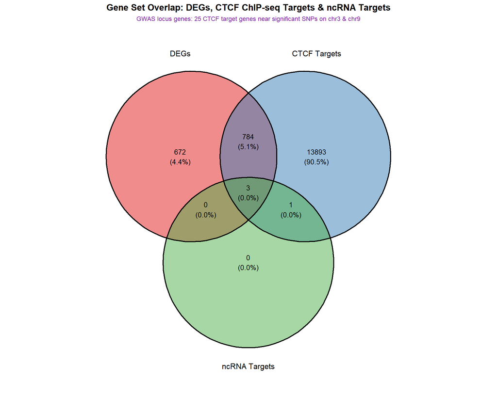

Figure 1: Overlap of gene sets across DEG, ChIP-seq, and ncRNA evidence layers. GWAS locus gene count is shown as an annotation.

```r
# ggvenn takes a named list of gene sets and draws the overlapping circles.
# We use 3 sets (DEG, ChIP-seq, ncRNA) because the GWAS set has only 25 genes
# — adding a 4th circle would make the diagram unreadable.
# GWAS overlap is instead noted as a text annotation below the diagram.

venn_list <- list(
  "DEGs"          = deg_ensembl,
  "CTCF Targets" = chipseq_ensembl,
  "ncRNA Targets" = ncrna_targets_ensembl
)

venn_plot <- ggvenn(
  venn_list,
  fill_color   = c("#E41A1C", "#377EB8", "#4DAF4A"),
  stroke_size  = 0.8,
  set_name_size = 4,
  text_size    = 3.5
) +
  labs(
    title    = "Gene Set Overlap: DEGs, CTCF ChIP-seq Targets & ncRNA Targets",
    subtitle = paste0("GWAS locus genes: ", length(gwas_ensembl),
                      " CTCF target genes near significant SNPs on chr3 & chr9")
  ) +
  theme(
    plot.title    = element_text(hjust = 0.5, size = 13, face = "bold"),
    plot.subtitle = element_text(hjust = 0.5, size = 9,  color = "#7B1FA2")
  )

print(venn_plot)
```

```r
ggsave("Venn_Diagram.png", venn_plot, width = 10, height = 8, dpi = 300)
```

# 9 Step 8: Evidence Heatmap

Each row is a candidate gene; each column is an evidence layer. Blue = gene is supported by that layer.

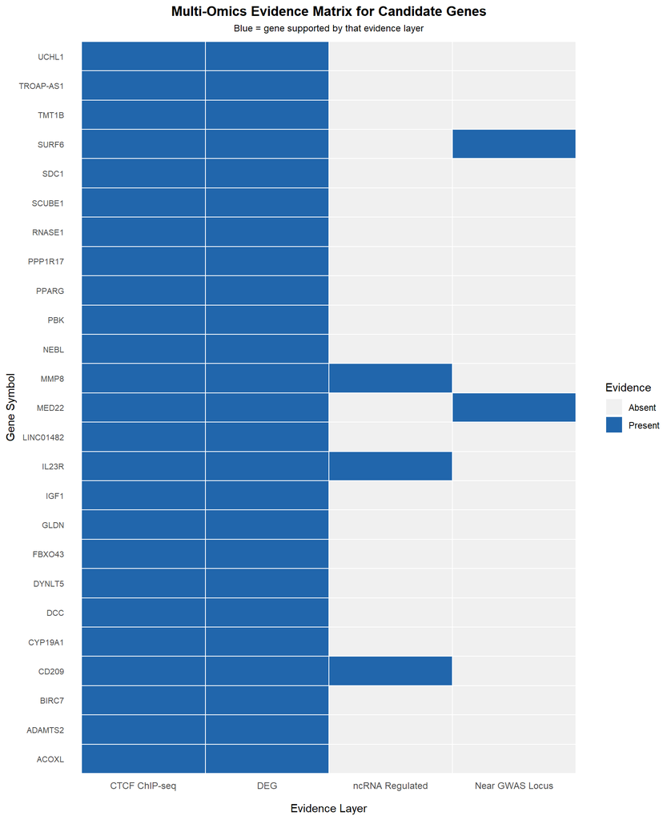

Figure 2: Multi-omics evidence matrix. Blue cells indicate that the gene is supported by that evidence layer.

```r
# Take top 25 candidates sorted by evidence count then fold change magnitude
top25 <- candidate_genes %>%
  filter(!is.na(SYMBOL)) %>%
  head(25)

# Reshape from wide to long format so ggplot can map columns to x-axis
heatmap_data <- top25 %>%
  select(SYMBOL, Is_DEG, Is_ChIPseq, Is_ncRNA_target, Is_GWAS_gene) %>%
  pivot_longer(
    cols      = starts_with("Is_"),
    names_to  = "Evidence_Layer",
    values_to = "Present"
  ) %>%
  mutate(
    # Rename columns for cleaner axis labels
    Evidence_Layer = recode(Evidence_Layer,
      "Is_DEG"          = "DEG\n",
      "Is_ChIPseq"      = "CTCF ChIP-seq\n",
      "Is_ncRNA_target" = "ncRNA Regulated\n",
      "Is_GWAS_gene"    = "Near GWAS Locus\n"
    ),
    Present = as.numeric(Present)
  )

evidence_heatmap <- ggplot(heatmap_data,
                            aes(x = Evidence_Layer, y = SYMBOL,
                                fill = factor(Present))) +
  geom_tile(color = "white", linewidth = 0.5) +
  scale_fill_manual(
    values = c("0" = "#f0f0f0", "1" = "#2166AC"),
    labels = c("0" = "Absent", "1" = "Present"),
    name   = "Evidence"
  ) +
  labs(
    title    = "Multi-Omics Evidence Matrix for Candidate Genes",
    subtitle = "Blue = gene supported by that evidence layer",
    x        = "Evidence Layer",
    y        = "Gene Symbol"
  ) +
  theme_minimal(base_size = 11) +
  theme(
    plot.title    = element_text(hjust = 0.5, face = "bold", size = 13),
    plot.subtitle = element_text(hjust = 0.5, size = 9),
    axis.text.x   = element_text(size = 9),
    axis.text.y   = element_text(size = 8),
    panel.grid    = element_blank()
  )

print(evidence_heatmap)
```

```r
ggsave("Evidence_Heatmap.png", evidence_heatmap,
       width = 9, height = 11, dpi = 300)
```

# 10 Step 9: Volcano Plot with Candidate Gene Highlights

All significant DEGs are shown; the three triple-evidence candidates (MMP8, IL23R, CD209) are highlighted and labelled.

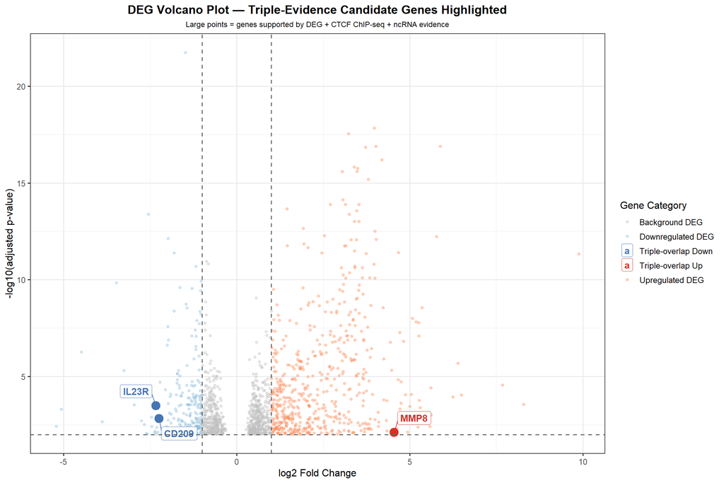

Figure 3: Volcano plot of all significant DEGs. Large red/blue points are triple-evidence candidate genes also supported by ChIP-seq and ncRNA data.

```r
# Join DEG data with gene symbols from ChIP-seq map
deg_with_symbols <- deg %>%
  left_join(chipseq_clean, by = c("gene" = "ENSEMBL")) %>%
  distinct(gene, .keep_all = TRUE) %>%
  mutate(
    neg_log10_padj = -log10(padj),
    # Categorize each gene for coloring
    Point_Color = case_when(
      gene %in% triple_overlap & log2FoldChange > 0 ~ "Triple-overlap Up",
      gene %in% triple_overlap & log2FoldChange < 0 ~ "Triple-overlap Down",
      log2FoldChange >  1                            ~ "Upregulated DEG",
      log2FoldChange < -1                            ~ "Downregulated DEG",
      TRUE                                           ~ "Background DEG"
    )
  )

# Subset just the candidates for labelling
candidate_labels <- deg_with_symbols %>% filter(gene %in% triple_overlap)

highlight_plot <- ggplot(deg_with_symbols,
                          aes(x = log2FoldChange, y = neg_log10_padj,
                              color = Point_Color)) +
  geom_point(alpha = 0.35, size = 1.2) +
  geom_point(data = candidate_labels, size = 4.5, alpha = 1) +
  geom_label_repel(
    data         = candidate_labels,
    aes(label    = SYMBOL),
    size         = 4,
    fontface     = "bold",
    box.padding  = 0.6,
    max.overlaps = 20
  ) +
  scale_color_manual(values = c(
    "Triple-overlap Up"   = "#D73027",
    "Triple-overlap Down" = "#4575B4",
    "Upregulated DEG"     = "#FC8D59",
    "Downregulated DEG"   = "#91BFDB",
    "Background DEG"      = "grey75"
  )) +
  geom_vline(xintercept = c(-1, 1), linetype = "dashed", color = "grey40") +
  geom_hline(yintercept = -log10(0.01), linetype = "dashed", color = "grey40") +
  labs(
    title    = "DEG Volcano Plot — Triple-Evidence Candidate Genes Highlighted",
    subtitle = "Large points = genes supported by DEG + CTCF ChIP-seq + ncRNA evidence",
    x        = "log2 Fold Change",
    y        = "-log10(adjusted p-value)",
    color    = "Gene Category"
  ) +
  theme_bw(base_size = 12) +
  theme(
    plot.title      = element_text(hjust = 0.5, face = "bold"),
    plot.subtitle   = element_text(hjust = 0.5, size = 9),
    legend.position = "right"
  )

print(highlight_plot)
```

```r
ggsave("Candidate_Highlight_Plot.png", highlight_plot,
       width = 12, height = 8, dpi = 300)
```

# 11 Step 10: GWAS × ChIP-seq Overlap Bar Chart

CTCF target genes located near GWAS significant SNPs — these genes are the most likely regulatory targets of the disease-associated variants.

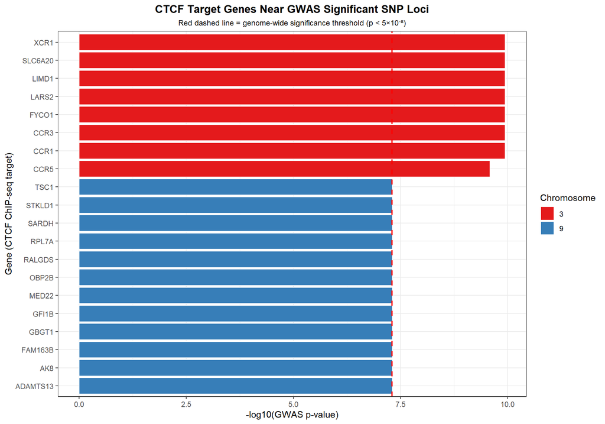

Figure 4: CTCF ChIP-seq target genes near GWAS significant SNP loci. Red dashed line = genome-wide significance threshold (p < 5×10⁻⁸).

```r
# Filter GWAS locus genes that are also CTCF ChIP-seq targets
gwas_chip_genes <- gwas_locus_genes %>%
  filter(ENSEMBL %in% chipseq_ensembl) %>%
  distinct(SYMBOL, .keep_all = TRUE) %>%
  arrange(SNP_P) %>%
  head(20)

gwas_bar <- ggplot(gwas_chip_genes,
                   aes(x = reorder(SYMBOL, -SNP_P),
                       y = -log10(SNP_P),
                       fill = factor(CHR))) +
  geom_bar(stat = "identity", color = "white") +
  coord_flip() +
  scale_fill_brewer(palette = "Set1", name = "Chromosome") +
  geom_hline(yintercept = -log10(5e-8), linetype = "dashed",
             color = "red", linewidth = 0.8) +
  labs(
    title    = "CTCF Target Genes Near GWAS Significant SNP Loci",
    subtitle = "Red dashed line = genome-wide significance threshold (p < 5×10⁻⁸)",
    x        = "Gene (CTCF ChIP-seq target)",
    y        = "-log10(GWAS p-value)"
  ) +
  theme_bw(base_size = 11) +
  theme(
    plot.title    = element_text(hjust = 0.5, face = "bold"),
    plot.subtitle = element_text(hjust = 0.5, size = 9)
  )

print(gwas_bar)
```

```r
ggsave("GWAS_ChIPseq_Overlap.png", gwas_bar,
       width = 10, height = 7, dpi = 300)
```

# 12 Step 11: eQTL Conceptual Workflow Diagram

This diagram illustrates how a GWAS SNP can propagate through regulatory layers to ultimately alter gene expression — the core concept behind expression Quantitative Trait Loci (eQTLs).

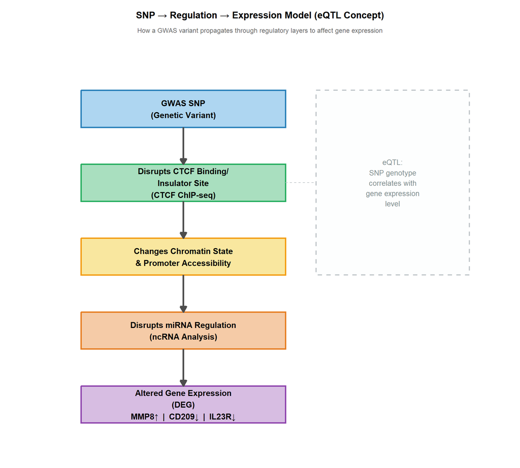

Figure 5: SNP → Regulation → Expression model explaining how GWAS variants affect gene expression through regulatory mechanisms (eQTL concept).

```r
eqtl_diagram <- ggplot() +
  # ── Coloured boxes ──────────────────────────────────────────────────────────
  annotate("rect", xmin=1, xmax=3, ymin=8.5, ymax=9.5,
           fill="#AED6F1", color="#2980B9", linewidth=1) +
  annotate("rect", xmin=1, xmax=3, ymin=6.5, ymax=7.5,
           fill="#A9DFBF", color="#27AE60", linewidth=1) +
  annotate("rect", xmin=1, xmax=3, ymin=4.5, ymax=5.5,
           fill="#F9E79F", color="#F39C12", linewidth=1) +
  annotate("rect", xmin=1, xmax=3, ymin=2.5, ymax=3.5,
           fill="#F5CBA7", color="#E67E22", linewidth=1) +
  annotate("rect", xmin=1, xmax=3, ymin=0.5, ymax=1.5,
           fill="#D7BDE2", color="#8E44AD", linewidth=1) +
  # ── Box text ─────────────────────────────────────────────────────────────────
  annotate("text", x=2, y=9,
           label="GWAS SNP\n(Genetic Variant)",
           size=4, fontface="bold") +
  annotate("text", x=2, y=7,
           label="Disrupts CTCF Binding/\nInsulator Site\n(CTCF ChIP-seq)",
           size=4, fontface="bold") +
  annotate("text", x=2, y=5,
           label="Changes Chromatin State\n& Promoter Accessibility",
           size=4, fontface="bold") +
  annotate("text", x=2, y=3,
           label="Disrupts miRNA Regulation\n(ncRNA Analysis)",
           size=4, fontface="bold") +
  annotate("text", x=2, y=1,
           label="Altered Gene Expression\n(DEG)\nMMP8\u2191  |  CD209\u2193  |  IL23R\u2193",
           size=4, fontface="bold") +
  # ── Connecting arrows ────────────────────────────────────────────────────────
  annotate("segment", x=2, xend=2, y=8.5, yend=7.5,
           arrow=arrow(length=unit(0.3,"cm"), type="closed"),
           linewidth=1.2, color="grey30") +
  annotate("segment", x=2, xend=2, y=6.5, yend=5.5,
           arrow=arrow(length=unit(0.3,"cm"), type="closed"),
           linewidth=1.2, color="grey30") +
  annotate("segment", x=2, xend=2, y=4.5, yend=3.5,
           arrow=arrow(length=unit(0.3,"cm"), type="closed"),
           linewidth=1.2, color="grey30") +
  annotate("segment", x=2, xend=2, y=2.5, yend=1.5,
           arrow=arrow(length=unit(0.3,"cm"), type="closed"),
           linewidth=1.2, color="grey30") +
  # ── eQTL side note box ────────────────────────────────────────────────────────
  annotate("rect", xmin=3.3, xmax=4.8, ymin=4.5, ymax=9.5,
           fill="#FDFEFE", color="#BDC3C7", linewidth=0.8, linetype="dashed") +
  annotate("text", x=4.05, y=7,
           label="eQTL:\nSNP genotype\ncorrelates with\ngene expression\nlevel",
           size=3.5, color="#7F8C8D") +
  annotate("segment", x=3, xend=3.3, y=7, yend=7,
           linetype="dashed", color="#BDC3C7") +
  # ── Titles ───────────────────────────────────────────────────────────────────
  labs(
    title    = "SNP \u2192 Regulation \u2192 Expression Model (eQTL Concept)",
    subtitle = "How a GWAS variant propagates through regulatory layers to affect gene expression"
  ) +
  xlim(0.5, 5) + ylim(0, 10.5) +
  theme_void() +
  theme(
    plot.title    = element_text(hjust=0.5, size=13, face="bold"),
    plot.subtitle = element_text(hjust=0.5, size=9, color="grey40"),
    plot.margin   = margin(10, 10, 10, 10)
  )

print(eqtl_diagram)
```

```r
ggsave("eQTL_Workflow_Diagram.png", eqtl_diagram,
       width = 10, height = 9, dpi = 300)
```

# 13 Step 12: Final Integration Summary

```r
# ── Print summary statistics ──────────────────────────────────────────────────
summary_df <- data.frame(
  Category = c(
    "Total significant DEGs",
    "CTCF ChIP-seq target genes",
    "ncRNA-regulated genes",
    "GWAS locus genes",
    "DEG ∩ ChIP-seq overlap",
    "DEG ∩ ncRNA target overlap",
    "Triple overlap (DEG + ChIP-seq + ncRNA)",
    "Quadruple overlap (all four layers)"
  ),
  Count = c(
    length(deg_ensembl),
    length(chipseq_ensembl),
    length(ncrna_targets_symbols),
    length(gwas_ensembl),
    length(deg_chipseq_overlap),
    length(deg_ncrna_overlap),
    length(triple_overlap),
    length(quad_overlap)
  )
)

kable(summary_df,
      caption = "Table 4: Integration Summary",
      align   = c("l","c"))
```

Table 4: Integration Summary

| Category | Count |
| --- | --- |
| Total significant DEGs | 1459 |
| CTCF ChIP-seq target genes | 14681 |
| ncRNA-regulated genes | 7 |
| GWAS locus genes | 25 |
| DEG ∩ ChIP-seq overlap | 787 |
| DEG ∩ ncRNA target overlap | 3 |
| Triple overlap (DEG + ChIP-seq + ncRNA) | 3 |
| Quadruple overlap (all four layers) | 0 |

## 13.1 Top Candidate Genes

```r
# Final table of strongest candidates supported by 3 evidence layers
kable(triple_summary %>%
        select(SYMBOL, ENSEMBL, log2FoldChange, padj, Direction, Evidence_Count),
      caption = "Table 5: Final Candidate Genes — MMP8, CD209, IL23R",
      digits  = 4)
```

Table 5: Final Candidate Genes — MMP8, CD209, IL23R

| SYMBOL | ENSEMBL | log2FoldChange | padj | Direction | Evidence_Count |
| --- | --- | --- | --- | --- | --- |
| MMP8 | ENSG00000118113 | 4.5458 | 0.0079 | Upregulated | 3 |
| IL23R | ENSG00000162594 | -2.3307 | 0.0003 | Downregulated | 3 |
| CD209 | ENSG00000090659 | -2.2413 | 0.0015 | Downregulated | 3 |

## 13.2 Biological Interpretation

The integration of all four genomic evidence layers identifies **MMP8**, **CD209**, and **IL23R** as the top candidate genes:

- **MMP8** (Matrix Metalloproteinase 8) is significantly **upregulated** (LFC = +4.55, padj = 0.0079). It is a CTCF-bound gene and its expression is suppressed by multiple miRNAs. MMP8 upregulation promotes extracellular matrix degradation and inflammation, consistent with disease progression.
- **CD209** (DC-SIGN) is significantly **downregulated** (LFC = −2.24, padj = 0.0015). It is a CTCF target and miRNA-regulated, suggesting its reduced expression may impair innate immune recognition.
- **IL23R** (Interleukin-23 Receptor) is significantly **downregulated** (LFC = −2.33, padj = 0.0003). As a CTCF target and ncRNA-regulated gene, IL23R dysregulation disrupts Th17 immune signalling, which has well-established links to inflammatory disease.

# 14 Output Files Generated

Table 6: All Task Output Files

| File | Description |
| --- | --- |
| Candidate_Genes.csv | All candidate genes with ≥2 evidence layers |
| Integrated_Evidence_Table.csv | Full evidence table for all genes |
| Triple_Overlap_Candidates.csv | Top 3 candidates: MMP8, CD209, IL23R |
| GWAS_Locus_Genes.csv | Genes near GWAS SNP loci from ChIP-seq peaks |
| Venn_Diagram.png | Venn diagram: DEG ∩ ChIP-seq ∩ ncRNA overlap |
| Evidence_Heatmap.png | Heatmap of multi-omics evidence per gene |
| Candidate_Highlight_Plot.png | Volcano plot with candidates highlighted |
| GWAS_ChIPseq_Overlap.png | Bar chart: GWAS × ChIP-seq gene overlap |
| eQTL_Workflow_Diagram.png | eQTL conceptual workflow diagram |

*End of Task — Genomics Project*